# GLMs

## OLS residuals

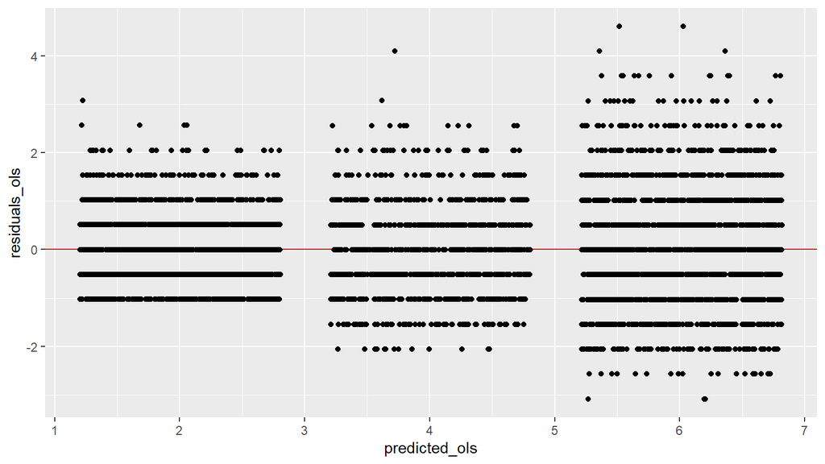

```r
tbl_poisson %>%
  ggplot(aes(predicted_ols, residuals_ols)) +
  geom_hline(color = 'red', yintercept = 0) +
  geom_jitter(height = 0)
```

## What have we simulated so far?

$$y_i \sim Pois(\mu_i) \\
y_i \sim\phi(\mu_i, \sigma)$$

In each case, $\mu_i$ is a linear transform of predictor information. For reasons that will be clear soon, let’s express the linear transform as $\eta_i$.

$$\eta_i = \beta_0 + \sum_j^{j=p}{\beta_j * x_{ij}}$$

## Write a function for the math

$$\eta_i = \beta_0 + \sum_j^{j=p}{\beta_j * x_{ij}}$$

```r
transform_x <- function(x, beta, intercept = 0){

  p <- length(beta)
  x <- matrix(x, ncol = p)
  beta <- matrix(beta, nrow = p)

  transformed_x <- x %*% beta %>%
    as.vector()

  intercept + transformed_x
}
```

## Calculate the log-likelihood for possible parameters

```r
dpois(tbl_poisson$y, transform_x(tbl_poisson$x, 0.9), log = TRUE) %>%
  sum()
## [1] -10086.83
dpois(tbl_poisson$y, transform_x(tbl_poisson$x, 1.0), log = TRUE) %>%
  sum()
## [1] -9980.984
dpois(tbl_poisson$y, transform_x(tbl_poisson$x, 1.1), log = TRUE) %>%
  sum()
## [1] -10076.78
```

`dpois()` is the Poisson probability mass function. We’ll cover it tomorrow.

`dpois()` is vectorised!! We’re using as many as `num_sims` different values of $\lambda$!

## The `glm()` function

```r
fit_glm <- glm(
    formula = y ~ 0 + x
  , data = tbl_poisson
  , family = poisson(link = 'identity')
)
```

## `glm()` maximizes log-likelihood

```r
logLik(fit_glm)
## 'log Lik.' -9980.977 (df=1)

fit_glm$coefficients
##         x
## 0.9991534

dpois(
    tbl_poisson$y
  , transform_x(tbl_poisson$x, fit_glm$coefficients, 0)
  , log = TRUE) %>%
  sum()
## [1] -9980.977
```

## A more complicated predictor space

```r
b0 <- 1
b1 <- 3
b2 <- -1/6
set.seed(1234)
tbl_poisson <- tibble(
    x_1 = runif(num_sims, 1, 10)
  , x_2 = runif(num_sims, 10, 50)
  , eta = matrix(c(x_1, x_2), ncol = 2) %>%
      transform_x(c(b1, b2), b0)
  , mu = eta
  , y = rpois(num_sims, mu)
)
```

## Visualize

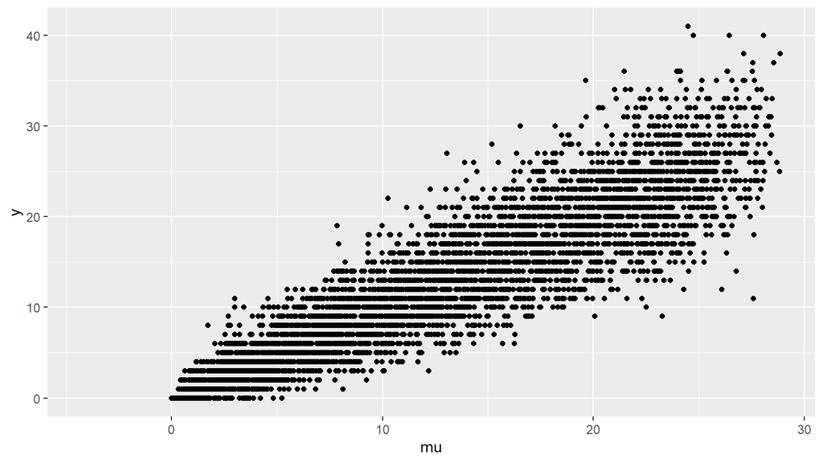

```r
tbl_poisson %>%
  ggplot(aes(mu, y)) +
  geom_point()
```

## But I have negative mus!

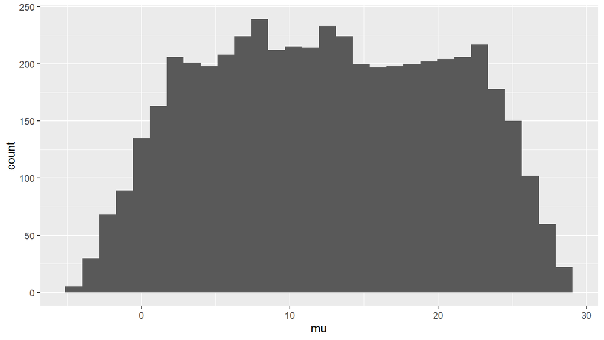

```r
tbl_poisson %>%
  ggplot(aes(mu)) +
  geom_histogram()
```

## We can fix that

The predictor space doesn’t work. Need a function which will map all real numbers to a positive number.

## Let’s augment our simulation engine

$$y_i \sim Pois(\mu_i) \\
y_i \sim\phi(\mu_i, \sigma)$$

$$y_i \sim g(\mu_i) = \eta_i \\
\eta_i = \beta_0 + \sum_j^{j=p}{\beta_j * x_{ij}}$$

I’m abusing statistical notation a bit.

## Try again with a link function

```r
b0 <- 1
b1 <- log(40) / 9
b2 <- log(0.25) / 30

set.seed(1234)
tbl_poisson <- tibble(
    x_1 = runif(num_sims, 1, 10)
  , x_2 = runif(num_sims, 10, 50)
  , eta = matrix(c(x_1, x_2), ncol = 2) %>%
      transform_x(c(b1, b2), b0)
  , mu = exp(eta)
  , y = rpois(num_sims, mu)
)
```

```r
tbl_poisson$eta %>% summary()
##    Min. 1st Qu.  Median    Mean 3rd Qu.    Max.
## -0.8753  0.9632  1.8465  1.8748  2.8006  4.5551
tbl_poisson$y %>% summary()
##    Min. 1st Qu.  Median    Mean 3rd Qu.    Max.
##    0.00    2.00    7.00   12.55   17.00  106.00
```

## Altogether

$\eta_i = \beta_0 + \sum_{j=1}^{p}{\beta_j*x_{ij}}$

$\mu_i = g^{-1}(\eta) \Leftrightarrow g(\mu_i) = \eta_i$

$E[Y_i] = \mu_i$

$E[Y] = \mu = g^{-1}(\eta) = g^{-1}(\beta_0 + \sum_{j=1}^{p}{\beta_j*x_j})$

# The Exponential Family

## The formula

According to McCullagh & Nelder

$$\begin{equation}
f(y;\theta,\phi)=exp\left[\frac{y\theta-b\theta}{a(\phi)}+c(y, \phi)\right]
\end{equation}$$

According to Dobson & Barnett

$$\begin{equation}
f(y;\theta)=exp\left[a(y)b(\theta) + c(\theta) + d(y)\right]
\end{equation}$$

$$\begin{equation}
f(y;\theta)=s(y)t(\theta)e^{a(y)b(\theta)}
\end{equation}$$

## The mechanics

1. $\eta_i = \beta_0 + \sum_{j=1}^{p}{\beta_j*x_{ij}}$
2. $\mu_i = g^{-1}(\eta) \Leftrightarrow g(\mu_i) = \eta_i$
3. $E[Y_i] = \mu_i$

## Examples

[output not shown]

## Mechanics in R

```
fit <- glm(
  formula = response ~ 1 + x_1 + x_2 + etc.
  , family = poisson(link = '') | binomial(link = 'logit' | 'probit') | Gamma()
  , data = your_data
)
```

1. The `formula` is business as usual
2. So is data
3. You’ll need to specify the family and (maybe) the link

```r
fit_pois <- glm(
  formula = y ~ x_1 + x_2
  , family = poisson()
  , data = tbl_poisson
)
```

# Predictions

## The link changes things

The default is to make predictions on the *predictor* space, not the *response* space.

$\eta$ vs. $\mu$

## Predictions

```r
predict(fit_pois) %>% head()
##        1        2        3        4        5        6
## 1.219358 2.932477 1.903901 2.049707 3.956181 1.995733
predict(fit_pois, type = 'response') %>% head()
##         1         2         3         4         5         6
##  3.385013 18.774072  6.712027  7.765623 52.257368  7.357597
```

```r
predict(fit_pois) %>% head() %>% fit_pois$family$linkinv()
##         1         2         3         4         5         6
##  3.385013 18.774072  6.712027  7.765623 52.257368  7.357597
```

# Diagnostics

## Diagnostics

```r
library(broom)

tbl_model_diagnostics <- fit_pois %>%
  glance()
```

Model diagnostics for a Poisson GLM

| null.deviance | df.null | logLik | AIC | BIC | deviance | df.residual |
| --- | --- | --- | --- | --- | --- | --- |
| 74066.54 | 4999 | -11641.14 | 23288.27 | 23307.82 | 5253.958 | 4997 |

## Deviance

Toy data set for illustration

```r
toy_rows <- 10
tbl_poisson_toy <- tbl_poisson %>%
  slice(seq_len(toy_rows))
```

```r
fit_worst <- tbl_poisson_toy %>%
  glm(
      formula = y ~ 1
    , family = poisson
  )

logLik(fit_worst)
## 'log Lik.' -92.40229 (df=1)
```

## Form a crazy predictive matrix

10 rows and 10 parameters.

```r
my_matrix <- diag(toy_rows)
colnames(my_matrix) <- paste0("P", seq_len(toy_rows))
my_matrix <- my_matrix[, -toy_rows]
```

## And it looks like this

| P1 | P2 | P3 | P4 | P5 | P6 | P7 | P8 | P9 |
| --- | --- | --- | --- | --- | --- | --- | --- | --- |
| 1 | 0 | 0 | 0 | 0 | 0 | 0 | 0 | 0 |
| 0 | 1 | 0 | 0 | 0 | 0 | 0 | 0 | 0 |
| 0 | 0 | 1 | 0 | 0 | 0 | 0 | 0 | 0 |
| 0 | 0 | 0 | 1 | 0 | 0 | 0 | 0 | 0 |
| 0 | 0 | 0 | 0 | 1 | 0 | 0 | 0 | 0 |
| 0 | 0 | 0 | 0 | 0 | 1 | 0 | 0 | 0 |
| 0 | 0 | 0 | 0 | 0 | 0 | 1 | 0 | 0 |
| 0 | 0 | 0 | 0 | 0 | 0 | 0 | 1 | 0 |
| 0 | 0 | 0 | 0 | 0 | 0 | 0 | 0 | 1 |
| 0 | 0 | 0 | 0 | 0 | 0 | 0 | 0 | 0 |

```r
tbl_poisson_toy <- tbl_poisson_toy %>%
  bind_cols(as_tibble(my_matrix))

best_formula <- paste(
    "y ~ 1 + "
  , paste(colnames(my_matrix), collapse = "+")) %>%
  as.formula()

best_formula
## y ~ 1 + P1 + P2 + P3 + P4 + P5 + P6 + P7 + P8 + P9
## <environment: 0x000000001f927a38>

fit_best <- tbl_poisson_toy %>%
  glm(
      formula = best_formula
    , family = poisson
  )

logLik(fit_best)
## 'log Lik.' -17.47104 (df=10)
logLik(fit_worst)
## 'log Lik.' -92.40229 (df=1)
```

## Null deviance

Double the distance between the “best”/saturated and the worst models.

```r
as.double(2 * (logLik(fit_best) - logLik(fit_worst)))
## [1] 149.8625
fit_best$null.deviance
## [1] 149.8625
fit_worst$null.deviance
## [1] 149.8625
```

Every model will have deviance values below this one. We want them to be a LOT lower.

## Deviance

(Residual) deviance is the distance between *our* model and the saturated model.

```r
fit_toy <- tbl_poisson_toy %>%
  glm(
    formula = y ~ 1 + x_1 + x_2
  , family = poisson
)

fit_toy$deviance
## [1] 11.10277
as.double(2 * (logLik(fit_best) - logLik(fit_toy)))
## [1] 11.10277
```

## Back at our non-toy model

```r
fit_pois <- glm(
    formula = y ~ 1 + x_1 + x_2
  , data = tbl_poisson
  , family = poisson
)

fit_pois$null.deviance
## [1] 74066.54
fit_pois$deviance
## [1] 5253.958
```

## Can we do better

```r
fit_pois_x1 <- glm(
    data = tbl_poisson
  , formula = y ~ 1 + x_1
  , family = poisson
)

fit_pois_x1$deviance
## [1] 21138.66
fit_pois$deviance
## [1] 5253.958
```

## AIC and BIC

Unlike $r^2$, there are no *absolute* metrics of model quality. Everything is relative.

AIC and BIC are measures of the likelihood which penalize for model complexity.

$$\begin{equation}
AIC = 2[-ln(L) + p]
\end{equation}$$

$$\begin{equation}
BIC = -2L+p*ln(n)
\end{equation}$$

AIC is like bad cholesterol. Lower is good.

Think: maximizing log-likelihood, is the same as dropping *negative* log-likelihood close to zero.

## AIC in R

```r
fit_pois_simple <- tbl_poisson %>%
  glm(
      formula = y ~ 1 + x_1
    , family = poisson
  )

fit_pois_simple$aic
## [1] 39170.98
fit_pois$aic
## [1] 23288.27
```

## Coefficients

```r
tbl_coef_diagnostics <- fit_pois %>%
  broom::tidy()
```

Coefficient diagnostics

| term | estimate | std.error | statistic | p.value |
| --- | --- | --- | --- | --- |
| (Intercept) | 1.0100832 | 0.0186697 | 54.10286 | 0 |
| x_1 | 0.4089281 | 0.0020357 | 200.87392 | 0 |
| x_2 | -0.0460005 | 0.0003789 | -121.40834 | 0 |

## Residuals

$$\begin{equation}
r^D_{i}=sign(y_i - \mu_i)\sqrt{d_i}
\end{equation}$$

Individual deviance expressions

| Family | $d_i$ |
| --- | --- |
| Normal | $\left(y_i - \hat{\mu}\right)^2$ |
| Poissson | $2*\left(y * log\left(y_i / \hat{\mu}\right) - \left(y_i - \hat{\mu} \right) \right)$ |
| binomial | $2*\left(y_i * log(y_i / \hat{\mu}) + (m - y_i) log\left[\frac{m - y_i}{m - \hat{\mu}} \right] \right)$ |
| gamma | $2*\left(-log\left(y_i / \hat{\mu} \right) + \frac{\left(y_i - \hat{\mu} \right)}{\hat{\mu}} \right)$ |

$$\begin{equation}
r^{s}_{i}=\frac{r^D_{i}}{\phi\sqrt{1 - h_i}}
\end{equation}$$

```r
hat_matrix <- fit_pois %>%
  influence() %>%
  pluck('hat')

phi <- fit_pois %>%
  summary() %>%
  pluck('dispersion')
```

```r
tbl_residual <- tbl_poisson %>%
  dplyr::select(y) %>%
  mutate(
      predicted_response = predict(fit_pois, type = 'response')
    , resid_deviance = residuals(fit_pois)
    , resid_pearson = rstandard(fit_pois, type = 'pearson')
  ) %>%
  mutate(
      hat = hat_matrix
    , phi = phi
    , scale_factor = phi * sqrt((1 - hat))
    , resid_deviance_standard_manual = resid_deviance / scale_factor
    , resid_deviance_standard = rstandard(fit_pois, type = 'deviance')
  )
```

## Manual calculation matches the formula

Manual calculation of standardized deviance residuals

| resid_deviance | resid_deviance_standard_manual | resid_deviance_standard |
| --- | --- | --- |
| -0.8155882 | -0.8158225 | -0.8158225 |
| -0.1798988 | -0.1799489 | -0.1799489 |
| 1.5139117 | 1.5141712 | 1.5141712 |
| -1.0623363 | -1.0625101 | -1.0625101 |
| -0.7400043 | -0.7407039 | -0.7407039 |
| -0.5172107 | -0.5173063 | -0.5173063 |

## Visualization of residuals

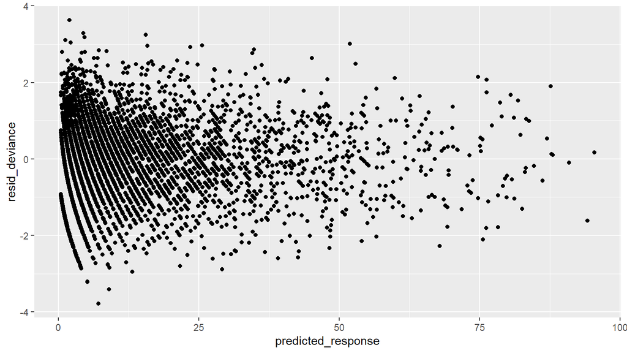

```r
tbl_residual %>%
  ggplot(aes(predicted_response, resid_deviance)) +
  geom_point()
```

## Transforms

Residual scale transformations

| Distribution | Transform |
| --- | --- |
| Normal | $\hat{\mu}$ |
| Poisson | $2*sqrt{\hat{\mu}}$ |
| Binomial | $2*sin^-1\sqrt{\hat{\mu}}$ |
| Gamma | $2*log{\hat{\mu}}$ |
| Inverse Gaussian | $-2\hat{\mu}^{-1/2}$ |

```r
tbl_residual <- tbl_residual %>%
  mutate(
      predicted_response_scaled = 2 * (predicted_response %>% sqrt)
  )

plt_standard <- tbl_residual %>%
  ggplot(aes(predicted_response, resid_deviance_standard)) +
  geom_point()

plt_adj <- tbl_residual %>%
  ggplot(aes(predicted_response_scaled, resid_deviance_standard)) +
  geom_point()
```

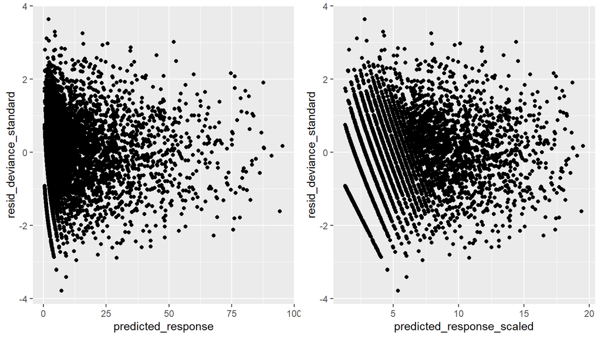

```r
library(gridExtra)
grid.arrange(plt_standard, plt_adj, nrow = 1)
```

# Offsets and weights

## What’s an offset?

An offset can be thought of as a predictor whose coefficient is constrained to be one.

Examples:

- Predict number of hits, using at-bats. # of hits -> batting average.
- Predict number of claims using exposure. Actually predicting the claim *rate*.

## In mathy terms

$$\begin{equation}
\eta_i = {Offset}_i + \beta_0 + \sum_j^{j=P}{\beta_j * x_{ij}}
\end{equation}$$

$$\begin{aligned}
E[Y]&=\mu_i \\
&= g^{-1}(\eta_i) \\
&= exp\left(\eta_i \right) \\
&= exp\left({Offset} + \beta_0 + \sum{\beta_j*x_{j}}\right) \\
&=exp\left(Offset\right) * exp\left(\beta_0 + \sum{\beta_j*x_{j}}\right)
\end{aligned}$$

## Why you should care

- There is a temptation to conflate offsets with credibility. Not the same thing.
- The `weight` parameter
- Algebraically it shakes out similarly. But very important in trying to understand *what* you’re modeling.
- Also some utility: backout fixed pricing mods

Read this paper: https://www.casact.org/pubs/forum/09wforum/yan_et_al.pdf

Read section 5.6.2.2 of [this book](https://www.cambridge.org/core/books/predictive-modeling-applications-in-actuarial-science/82A7E5B9545B1BEDD7F6A7491265113A).

# Logistic regression

## Link functions are useful!

$$\begin{equation}
f(\alpha)=\frac{exp(\alpha)}{exp(\alpha)+1}
\end{equation}$$

```r
logistic <- function(x) {
  exp(x) / (exp(x) + 1)
}
```

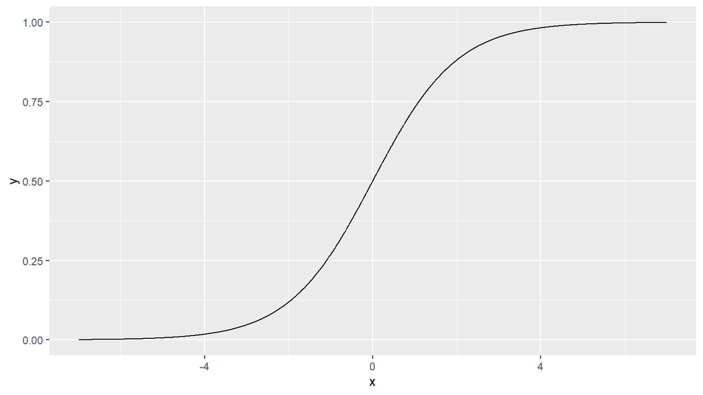

```r
tibble(
    x = runif(num_sims, -7, 7)
  , y = logistic(x)
) %>%
  ggplot(aes(x, y)) +
  geom_line()
```

## Simulate

```r
b0 <- -5
b1 <- 0.1
b2 <- 0.1
num_sims <- 500

set.seed(1234)
tbl_logistic <- tibble(
    x_1 = runif(num_sims, 0, 100)
  , x_2 = runif(num_sims, -10, 60)
  , eta = transform_x(cbind(x_1, x_2), c(b1, b2), b0)
  , mu = logistic(eta)
  , claim = rbinom(num_sims, 1, mu)
)
```

## Visualize

```r
plt_x_1 <- tbl_logistic %>%
  ggplot(aes(x_1, claim)) +
  geom_jitter(height = 0.2)

plt_x_2 <- tbl_logistic %>%
  ggplot(aes(x_2, claim)) +
  geom_jitter(height = 0.2)
```

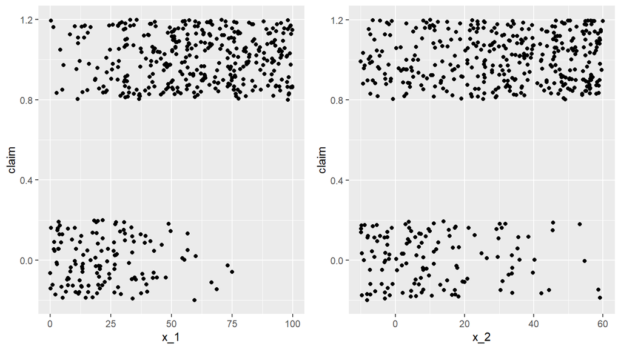

```r
grid.arrange(
    plt_x_1
  , plt_x_2
  , nrow = 1
)
```

## `glm()`

```r
fit_logistic <- glm(
    formula = claim ~ 1 + x_1 + x_2
  , data = tbl_logistic
  , family = binomial(link = 'logit')
)
```

## A simple classifier

```r
tbl_prob_50 <- crossing(
    x_1 = seq(0, 75, length.out = 500)
  , x_2 = seq(-10, 60, length.out = 500)
) %>%
  mutate(
    p = predict(fit_logistic, newdata = ., type = 'response')
  ) %>%
  filter(
    p > 0.49
  , p < 0.51
  )
```

## Visually

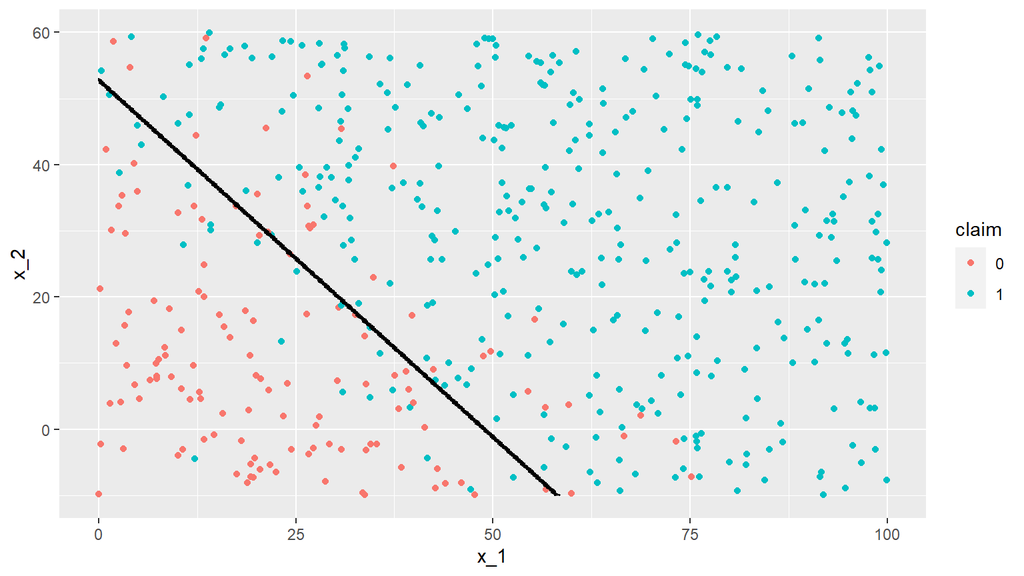

```r
tbl_logistic %>%
  mutate(claim = as.factor(claim)) %>%
  ggplot(aes(x_1, x_2, color = claim)) +
  geom_point() +
  geom_line(data = tbl_prob_50, aes(x_1, x_2), color = 'black')
```

# Actual example

## Loss reserves

```r
wrangle_triangle <- function(tbl_in) {

  tbl_in %>%
    group_by(GroupCode, AccidentYear) %>%
    arrange(Lag, .by_group = TRUE) %>%
    mutate(
      prior_paid = dplyr::lag(CumulativePaid)
      , prior_incurred = dplyr::lag(CumulativeIncurred)
      , incremental_paid = coalesce(CumulativePaid - prior_paid, CumulativePaid)
      , incremental_incurred = coalesce(CumulativeIncurred - prior_incurred, CumulativeIncurred)
      , ldf_paid = CumulativePaid / prior_paid
      , ldf_incurred = CumulativeIncurred / prior_incurred
    ) %>%
    ungroup() %>%
    mutate(
      lag_factor = as.factor(Lag)
      , ay_factor = as.factor(AccidentYear)
      , upper = DevelopmentYear <= 1997
    )
}
```

```r
library(raw)
data(medmal)
data(NJM_WC)

tbl_njm_wc <- NJM_WC %>%
  wrangle_triangle()

tbl_medmal <- medmal %>%
  wrangle_triangle()

tbl_upper <- tbl_medmal %>%
  filter(upper)

tbl_lower <- tbl_medmal %>%
  filter(!upper)

tbl_upper <- tbl_upper %>%
  filter(Lag > 1)

tbl_njm_wc <- tbl_njm_wc %>%
  filter(Lag > 1)
```

```r
fit_upper <- tbl_upper %>%
  glm(
    formula = incremental_paid ~ 0 + prior_paid:lag_factor
    , data = .
    , family = poisson
  )
## Error in eval(family$initialize): negative values not allowed for the 'Poisson' family
```

## Try again

```r
tbl_upper <- tbl_upper %>%
  group_by(lag_factor) %>%
  mutate(
    shift = -min(incremental_paid) %>% pmax(0)
    , incremental_paid_shifted = incremental_paid + shift
  ) %>%
  ungroup()

fit_upper <- tbl_upper %>%
  glm(
    formula = incremental_paid_shifted ~ 0 + prior_paid:lag_factor
    , data = .
    , family = poisson()
  )

tbl_upper <- tbl_upper %>%
  mutate(
    predicted = predict(fit_upper, type = 'response') - shift
  )
```

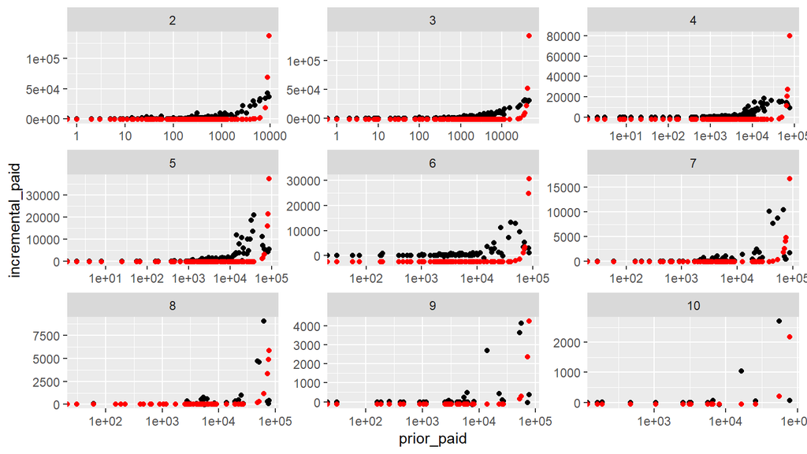

```r
tbl_upper %>%
  ggplot(aes(prior_paid)) +
  geom_point(aes(y = incremental_paid)) +
  geom_point(aes(y = predicted), color = 'red') +
  scale_x_log10() +
  facet_wrap(~ lag_factor, scales = 'free')
```

```r
fit_njm_wc <- tbl_njm_wc %>%
  glm(
      formula = incremental_paid ~ 0 + prior_paid:lag_factor
    , data = .
    , family = poisson(link = 'identity')
  )
```

```r
fit_njm_wc$coefficients %>%
  fit_njm_wc$family$linkinv() %>%
  unname()
## [1] 0.80973842 0.26560688 0.15843628 0.09054157 0.05764151 0.04145484 0.03024728
## [8] 0.02257429 0.01950248

tbl_njm_wc %>%
  group_by(Lag) %>%
  summarise(
    weighted_ldf = sum(incremental_paid) / sum(prior_paid)
  ) %>%
  pull(weighted_ldf)
## [1] 0.80973842 0.26560688 0.15843628 0.09054157 0.05764151 0.04145484 0.03024728
## [8] 0.02257429 0.01950248
```

# Conclusion

## What have we learned?

- The GLM is a generalization of OLS
- Exponential family of functions allows modeling of probabilities, and counts